# Project_1_gl2669

### Step 0 - Load all the required libraries

### Step 1 - Load the data to be cleaned and processed

```
## # A tibble: 6 x 5
##   song           year artist genre  lyrics
##   <chr>         <dbl> <chr>  <chr>  <chr>
## 1 when-you-wer~  2009 a      Hip-H~ "I stopped by the house we called our ~
## 2 careless-whi~  2009 a      Hip-H~ "I feel so unsure\nAs I take your hand~
## 3 2-59           2007 a      Hip-H~ "Mark:] Sunday football I got boot off~
## 4 power-of-des~  2007 a      Hip-H~ "[Chris:] Fallin' for a fantasy\nI thr~
## 5 you-re-not-i~  2007 a      Hip-H~ "something in the way we touch\nyou ho~
## 6 nothing        2007 a      Hip-H~ "Nothing\nAnd nothing's where you're a~
```

### Step 2 - stemming words

```
## # A tibble: 29,024,452 x 6
##    song                   year artist genre   linenumber word
##    <chr>                 <dbl> <chr>  <chr>        <int> <chr>
##  1 when-you-were-with-me  2009 a      Hip-Hop          1 i
##  2 when-you-were-with-me  2009 a      Hip-Hop          1 stopped
##  3 when-you-were-with-me  2009 a      Hip-Hop          1 by
##  4 when-you-were-with-me  2009 a      Hip-Hop          1 the
##  5 when-you-were-with-me  2009 a      Hip-Hop          1 house
##  6 when-you-were-with-me  2009 a      Hip-Hop          1 we
##  7 when-you-were-with-me  2009 a      Hip-Hop          1 called
##  8 when-you-were-with-me  2009 a      Hip-Hop          1 our
##  9 when-you-were-with-me  2009 a      Hip-Hop          1 home
## 10 when-you-were-with-me  2009 a      Hip-Hop          1 it
## # ... with 29,024,442 more rows
```

### stop words

```
## # A tibble: 9,519,877 x 6
##    song                   year artist genre   linenumber word
##    <chr>                 <dbl> <chr>  <chr>        <int> <chr>
##  1 when-you-were-with-me  2009 a      Hip-Hop          1 stopped
##  2 when-you-were-with-me  2009 a      Hip-Hop          1 house
##  3 when-you-were-with-me  2009 a      Hip-Hop          1 called
##  4 when-you-were-with-me  2009 a      Hip-Hop          1 home
##  5 when-you-were-with-me  2009 a      Hip-Hop          1 rundown
##  6 when-you-were-with-me  2009 a      Hip-Hop          1 grass
##  7 when-you-were-with-me  2009 a      Hip-Hop          1 overgrown
##  8 when-you-were-with-me  2009 a      Hip-Hop          1 screen
##  9 when-you-were-with-me  2009 a      Hip-Hop          1 door
## 10 when-you-were-with-me  2009 a      Hip-Hop          1 wind
## # ... with 9,519,867 more rows
```

### count and find the most common words in all the lyrics as a whole

```
## # A tibble: 302,110 x 3
## # Groups:   genre [12]
##    genre word      n
##    <chr> <chr> <int>
##  1 Rock  love  69317
##  2 Rock  time  49665
##  3 Pop   love  48100
##  4 Rock  yeah  33202
##  5 Rock  baby  29137
##  6 Rock  gonna 28153
##  7 Rock  feel  27104
##  8 Rock  life  26701
##  9 Rock  day   24500
## 10 Rock  night 24428
## # ... with 302,100 more rows
```

```
##  [1] "Country"       "Electronic"    "Folk"          "Hip-Hop"
##  [5] "Indie"         "Jazz"          "Metal"         "Not Available"
##  [9] "Other"         "Pop"           "R&B"           "Rock"
```

### WordCloud

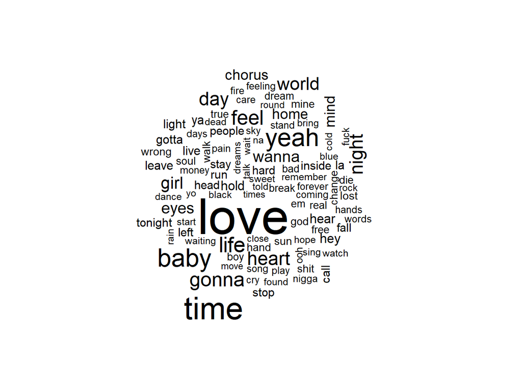

### positive vs negative wordcloud

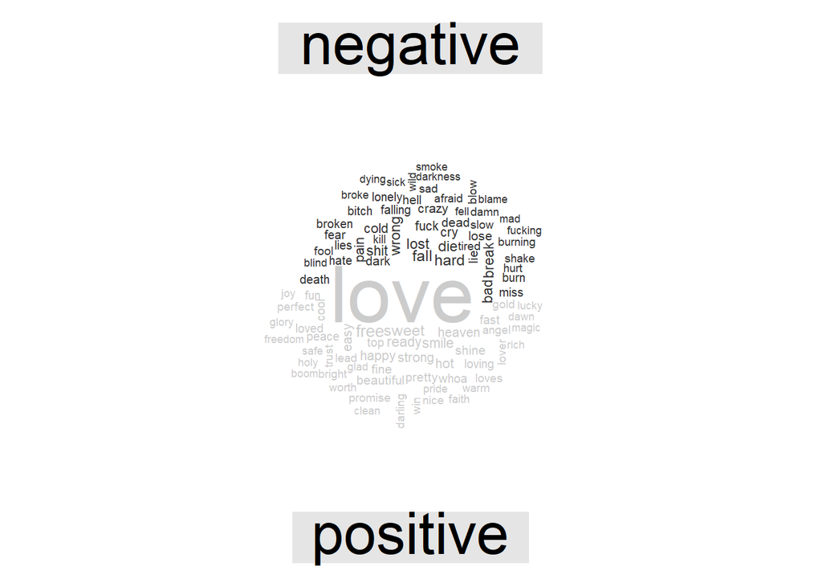

### summary plot

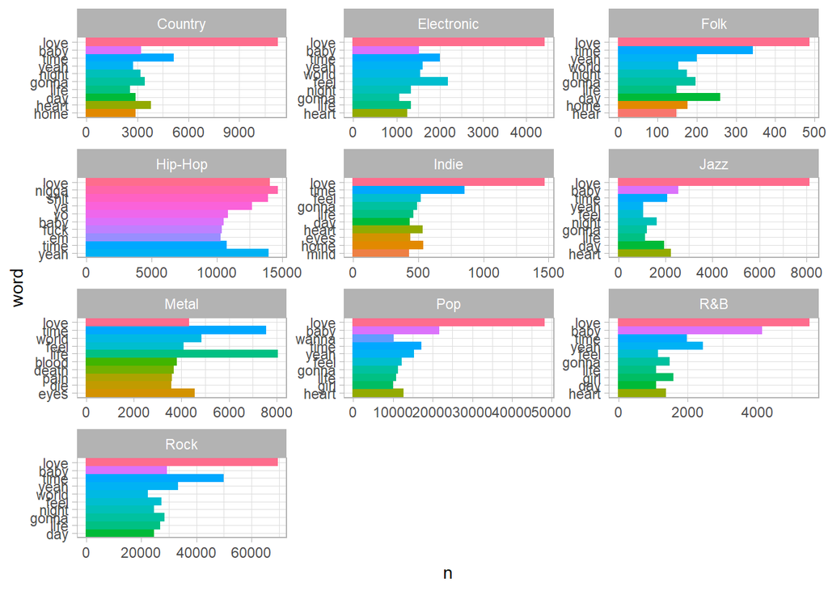

### tf-idf

```
## # A tibble: 302,110 x 6
## # Groups:   genre [12]
##    genre   word          n       tf   idf  tf_idf
##    <chr>   <chr>     <int>    <dbl> <dbl>   <dbl>
##  1 Other   herbo        13 0.000995 2.48  0.00247
##  2 Other   niggas       78 0.00597  0.405 0.00242
##  3 Hip-Hop niggas    10155 0.00561  0.405 0.00227
##  4 Other   nigga       137 0.0105   0.182 0.00191
##  5 Other   baecation     8 0.000612 2.48  0.00152
##  6 Other   bibbity       8 0.000612 2.48  0.00152
##  7 Hip-Hop nigga     14614 0.00807  0.182 0.00147
##  8 Other   kneeewww      7 0.000536 2.48  0.00133
##  9 Indie   mooday       41 0.000531 2.48  0.00132
## 10 R&B     babyface    170 0.00113  1.10  0.00124
## # ... with 302,100 more rows
```

# plot after tf-idf

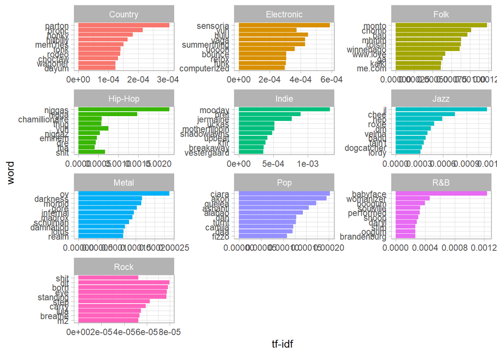

### Summary of 12 types of lyrics

### Rock, Pop and Hip-Hop are the three largest lyrics.

### Feeling is for most artists who want to deliver from the songs. (key word: feel)

### Inspiration is always from the lives of the artists. (key word: life)

### Love is the main theme for most of the lyrics excerpt for the Metal (Love)

### Not only Hip-Hop but also other lyrics like to use rhyme words such as “Yeah”

Top Frequencies words based on the lyrics:

Category 1: Positive common words: love, time, yeah, life, world, wanna, gonna, day, night, feel

rock: love, time, yeah, baby, gonna, feel, life, day. night, world, heart pop: love, baby, time, yeah, heart, feel, gonna, life, wanna Country: love, time, heart, gonna, baby, night, day, home, yeah, life Electronic: love, feel, time, yeah, world, baby, night, life, gonna, wanna Jazz: love, baby, heart, time, day, night, gonna, life, feel Indie: love, time, home, heart, feel, gonna, life, eyes, day, mind Folk: love, time, day, yeah, gonna, home, night, world, hear, life, heart, baby, sea

Category 2: Rhyme R&B: love, baby, yeah, time, girl, gonna, heart, feel, day, life, wanna Hip-Hop: nigga, love, yeah, shit, ya, yo, time, baby, fuck, em, niggas

Category 3: Negative Metal: life, time, world, eyes, love, feel, blood, death, pain, dies

Rock, pop, country, electronic, Jazz, Indie and Folk songs are about love and other positive feelings. Some artists talk about home, world and life (day and night) while others talk about the people they are in love with.

Hip-Hop are usually about love stories and include rhyme like ya, yo, em.

Metal is the only one which has many negative words (death, blood) as top frequencies words.

### References

https://www.tidytextmining.com/tidytext.html